# Semantički indeks geopolitičke nestabilnosti

Mjerenje geopolitičkih rizika kroz analizu medijskog diskursa

Author

GIMES Research

Published

1. siječnja 2026.

# 1 Uvod

Ovaj dokument konstruira semantičke indekse geopolitičke nestabilnosti temeljene na analizi medijskog diskursa. Metodologija prati strukturu semantičkog indeksiranja prilagođenu geopolitičkoj domeni te mjeri intenzitet aktivnosti, sentiment eskalacije i razinu neizvjesnosti povezanu s međunarodnim odnosima i sukobima.

## 1.1 Konfiguracija domene

Konfiguracija analize

| Parametar | Vrijednost |
| --- | --- |
| Domena | geopolitical |
| Jezik | hr |
| Agregacija | monthly |
| Broj indeksa | 10 |
| Broj sektora | 12 |
| Raspon normalizacije | 0 do 100 |

**Metodološki okvir**

Indeksi geopolitičke nestabilnosti konstruiraju se primjenom leksičkog pristupa na korpus medijskih tekstova. Svaki indeks slijedi standardnu formulu prilagođenu specifičnostima geopolitičke domene.

**Indeks aktivnosti (xAI)**
$$xAI_t = normalize_{01}\left(\frac{\sum_{i \in M_t} terms_i}{N_t}\right) \times 100$$

**Indeks sentimenta (xSI)**
$$xSI_t = normalize_{01}\left(\frac{terms_t}{N_t} \times (1 + SR_t)\right) \times 100$$

Gdje je $SR = \frac{deeskalacija - eskalacija}{deeskalacija + eskalacija}$

**Indeks neizvjesnosti (xUI)**
$$xUI_t = normalize_{01}\left(\frac{uncertainty\_terms_t}{N_t}\right) \times 100$$

**Indeks budućih očekivanja (xFI)**
$$xFI_t = normalize_{01}\left(\frac{forward\_terms_t}{N_t}\right) \times 100$$

# 2 Eksploratorni pregled

Osnovne statistike dataseta

| Metrika | Vrijednost |
| --- | --- |
| Ukupan broj članaka | 218,162 |
| Vremenski raspon | 01.01.2021 do 08.01.2024 |
| Broj dana | 1102 |
| Prosječno članaka dnevno | 197.97 |
| Broj izvora | 114 |
| Medijan duljine članka | 2,560 |

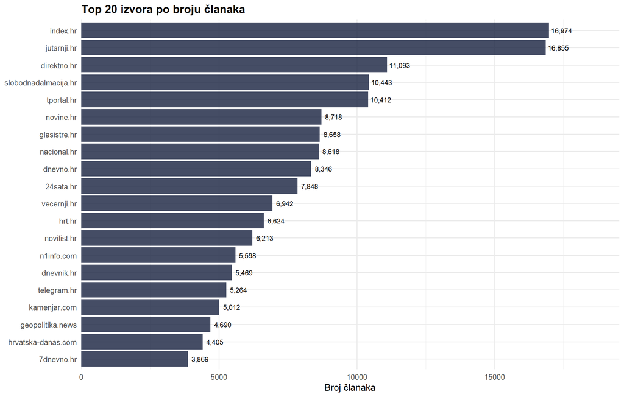

Top 20 izvora po broju članaka

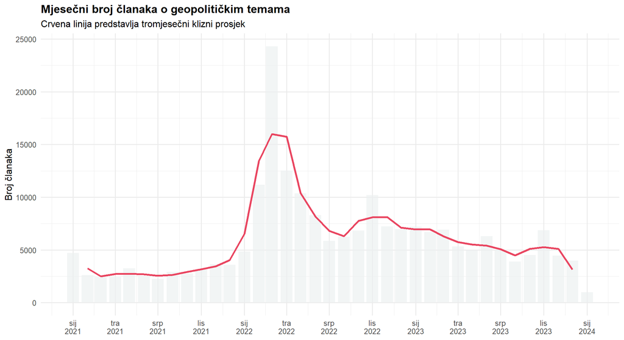

Mjesečni broj članaka

# 3 Semantička taksonomija

Taksonomija geopolitičkog diskursa organizirana je hijerarhijski u makro i mezo kategorije. Svaka kategorija definirana je skupom regularnih izraza koji obuhvaćaju morfološke varijante pojmova karakterističnih za hrvatski jezik.

**Prikaz kompletne taksonomije**

Struktura geopolitičke semantičke taksonomije

| Makro_kategorija | Meso_kategorija | Broj_pojmova |
| --- | --- | --- |
| sukobi_ratovi | rat_opce | 8 |
| sukobi_ratovi | invazija_okupacija | 5 |
| sukobi_ratovi | bojiste | 5 |
| sukobi_ratovi | ofenziva_defenziva | 6 |
| sukobi_ratovi | zrtve | 9 |
| rusija_ukrajina | rusija | 6 |
| rusija_ukrajina | ukrajina | 7 |
| rusija_ukrajina | ruski_rat | 4 |
| rusija_ukrajina | regije_ukrajina | 12 |
| rusija_ukrajina | wagner | 4 |
| izrael_bliski_istok | izrael | 7 |
| izrael_bliski_istok | palestina | 6 |
| izrael_bliski_istok | hamas | 8 |
| izrael_bliski_istok | hezbollah | 5 |
| izrael_bliski_istok | libanon | 5 |
| izrael_bliski_istok | iran | 6 |
| izrael_bliski_istok | sirija | 5 |
| izrael_bliski_istok | arapske_zemlje | 6 |
| nato_zapad | nato | 4 |
| nato_zapad | eu | 5 |
| nato_zapad | sad | 7 |
| nato_zapad | britanija | 5 |
| nato_zapad | njemacka | 5 |
| nato_zapad | francuska | 5 |
| kina_azija | kina | 9 |
| kina_azija | tajvan | 5 |
| kina_azija | juzno_kinesko_more | 5 |
| kina_azija | sjeverna_koreja | 6 |
| kina_azija | japan_juzna_koreja | 7 |
| kina_azija | indo_pacifik | 4 |
| balkan | srbija | 4 |
| balkan | kosovo | 5 |
| balkan | bih | 6 |
| balkan | crna_gora | 3 |
| balkan | madarska | 4 |
| balkan | turska | 6 |
| vojska_oruzje | vojska_opce | 5 |
| vojska_oruzje | kopnene_snage | 5 |
| vojska_oruzje | zrakoplovstvo | 6 |
| vojska_oruzje | mornarica | 5 |
| vojska_oruzje | dronovi | 5 |
| vojska_oruzje | rakete | 7 |
| vojska_oruzje | nuklearno | 7 |
| vojska_oruzje | vojna_pomoc | 8 |
| diplomacija | diplomacija_opce | 4 |
| diplomacija | pregovori | 4 |
| diplomacija | sankcije | 6 |
| diplomacija | summit | 4 |
| diplomacija | ujedinjeni_narodi | 7 |
| diplomacija | savezi_koalicije | 5 |
| terorizam_sigurnost | terorizam | 5 |
| terorizam_sigurnost | islamski_ekstremizam | 7 |
| terorizam_sigurnost | kiberneticka_sigurnost | 4 |
| terorizam_sigurnost | obaviestajne_sluzbe | 7 |
| terorizam_sigurnost | sigurnosna_politika | 3 |
| humanitarno | izbjeglice | 5 |
| humanitarno | humanitarna_pomoc | 4 |
| humanitarno | ratni_zlocini | 6 |
| humanitarno | civilne_zrtve | 3 |
| energetika_resursi | nafta_plin | 7 |
| energetika_resursi | energetska_sigurnost | 3 |
| energetika_resursi | nord_stream | 4 |
| energetika_resursi | kriticna_infrastruktura | 3 |
| informacijsko_ratovanje | dezinformacije | 5 |
| informacijsko_ratovanje | hibridno_ratovanje | 3 |
| informacijsko_ratovanje | utjecajne_operacije | 3 |

## 3.1 Leksikoni sentimenta i neizvjesnosti

Pregled leksikona

| Leksikon | Broj_pojmova |
| --- | --- |
| Deeskalacija | 31 |
| Eskalacija | 40 |
| Neizvjesnost | 40 |
| Forward looking | 25 |
| Intenzitet visoki | 17 |
| Intenzitet niski | 7 |
| Akteri državni | 9 |
| Akteri nedržavni | 8 |
| Akteri međunarodni | 7 |

## 3.2 Brojanje pojmova

# 4 Konstrukcija indeksa

## 4.1 Mjesečna agregacija

## 4.2 TF IDF ponderiranje

IDF težine po kategorijama (veća vrijednost označava veću diskriminativnost)

[output not shown]

## 4.3 Definicija indeksa

**Opis indeksa i metodologija**

| Indeks | Naziv | Opis |
| --- | --- | --- |
| GRI | Geopolitical Risk Index | Ukupna geopolitička aktivnost normalizirana po broju članaka |
| CII | Conflict Intensity Index | Intenzitet sukoba kombiniranjem Rusija Ukrajina i Bliski Istok tematika |
| ESI | Escalation Index | Razina eskalacije temeljena na omjeru eskalacijskih i deeskalacijskih pojmova |
| GUI | Geopolitical Uncertainty Index | Mjera neizvjesnosti u geopolitičkom diskursu |
| FGI | Forward Looking Geopolitical Index | Orijentacija na buduće događaje uključujući prognoze planove i očekivanja |
| RTI_E | Regional Tension Index East | Napetosti na istoku s fokusom na Rusiju i Ukrajinu |
| METI | Middle East Tension Index | Napetosti na Bliskom Istoku uključujući Izrael Hamas Hezbollah i Iran |
| WAI | Western Alliance Index | Aktivnost zapadnih institucija kao što su NATO EU i SAD |
| MAI | Military Activity Index | Vojna aktivnost i teme vezane uz oružje i vojsku |
| PCI | Principal Component Index | Prva glavna komponenta svih makro kategorija |

# 5 Vizualizacija indeksa

## 5.1 Glavni indeksi

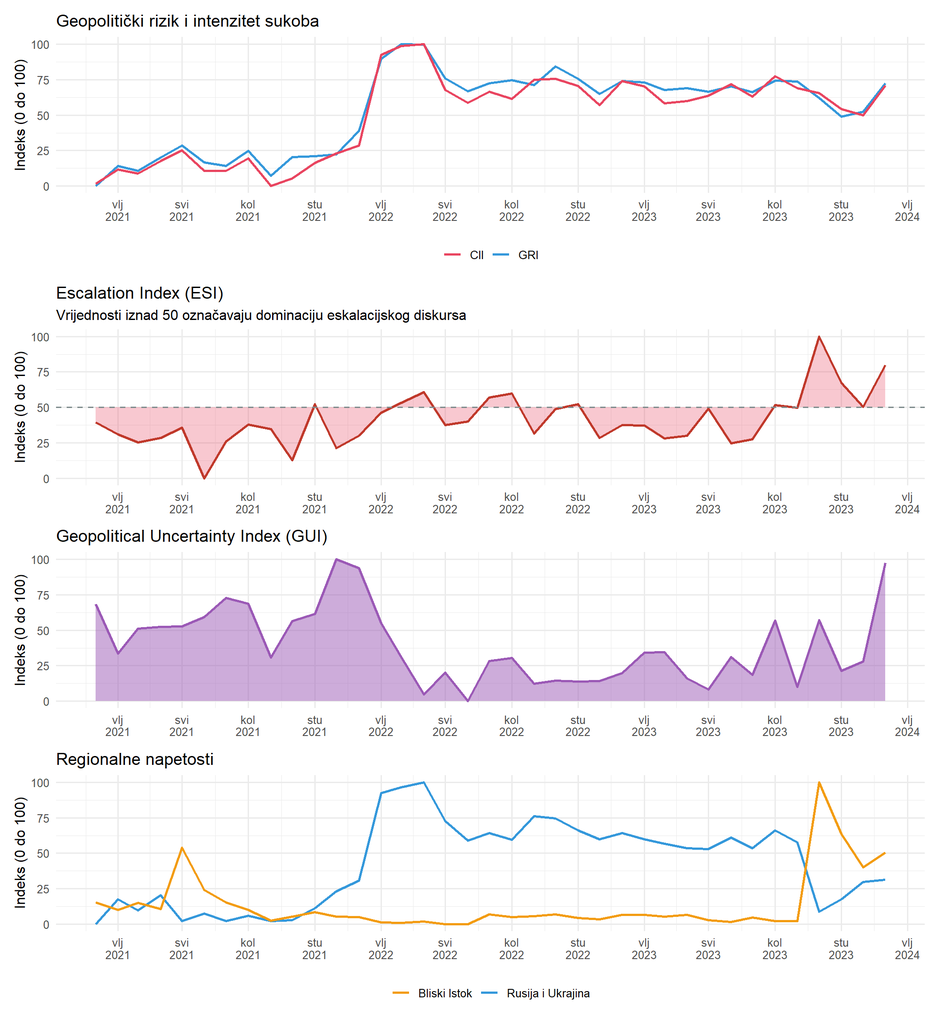

Glavni geopolitički indeksi

## 5.2 Vojna aktivnost i zapadni savezi

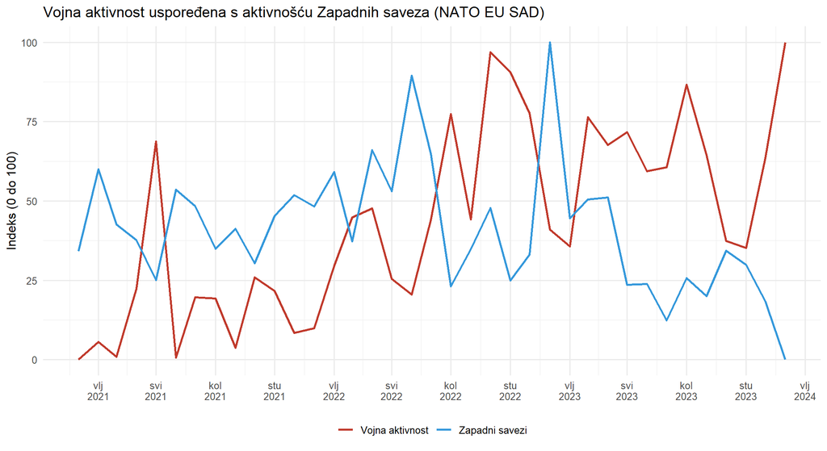

Vojna aktivnost i Zapadni savezi

## 5.3 Principal Component Index

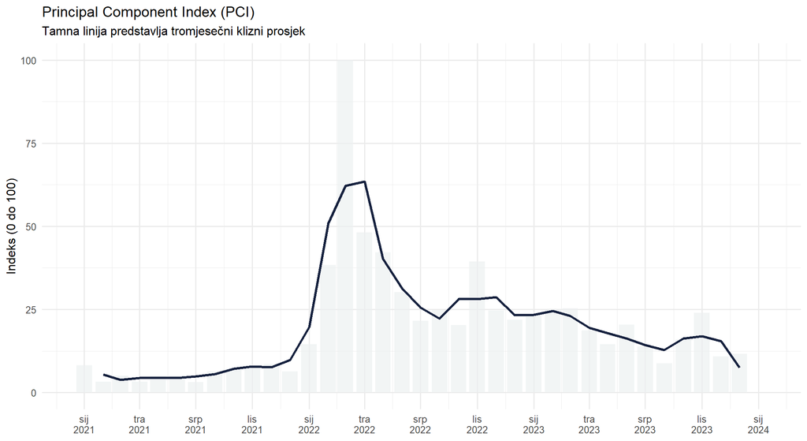

Principal Component Index s kliznim prosjekom

# 6 Regionalna i tematska analiza

## 6.1 Dinamika po regijama i temama

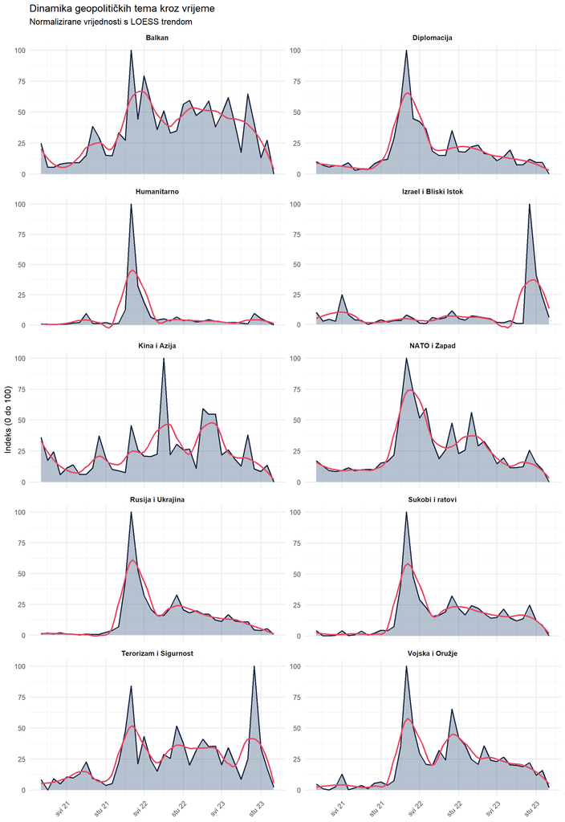

Dinamika geopolitičkih tema kroz vrijeme

## 6.2 Heatmapa geopolitičke aktivnosti

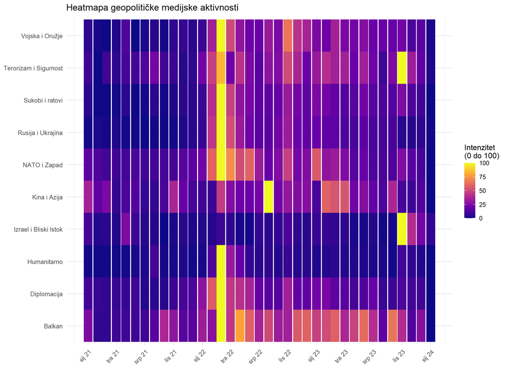

Heatmapa geopolitičke aktivnosti

## 6.3 Korelacijska struktura

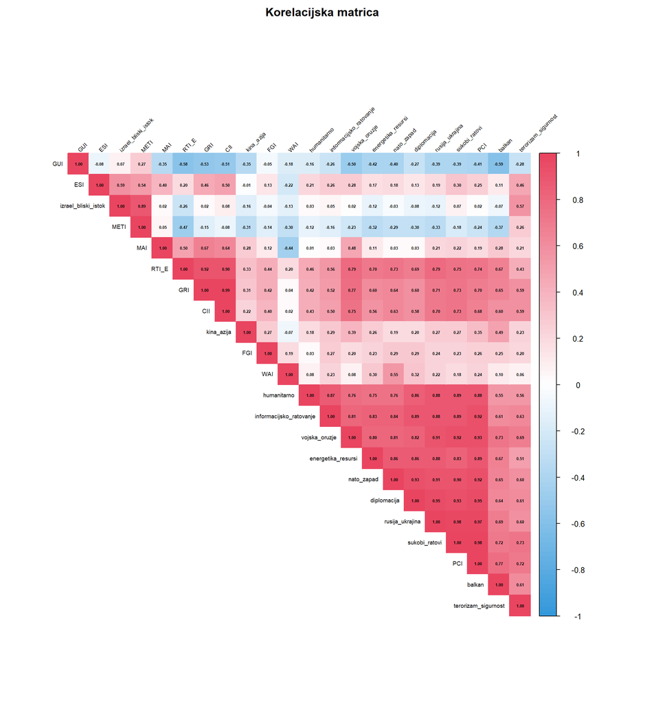

Korelacijska matrica tema i indeksa

# 7 Eskalacija i Deeskalacija analiza

## 7.1 Sentiment komponente

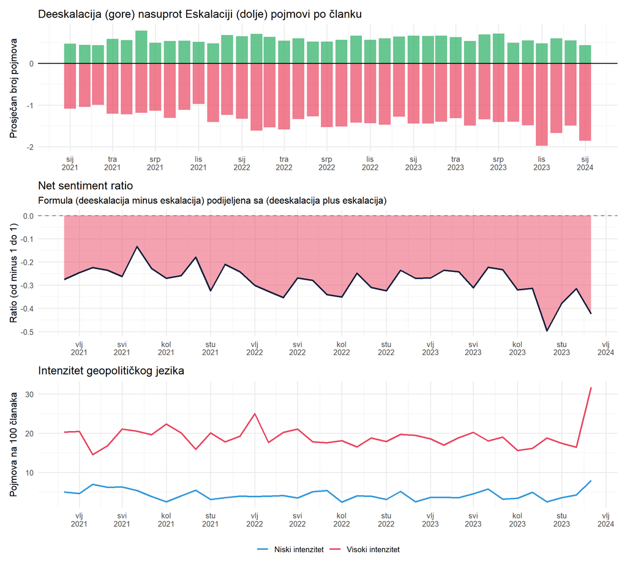

Eskalacija i Deeskalacija kroz vrijeme

## 7.2 Tipovi aktera

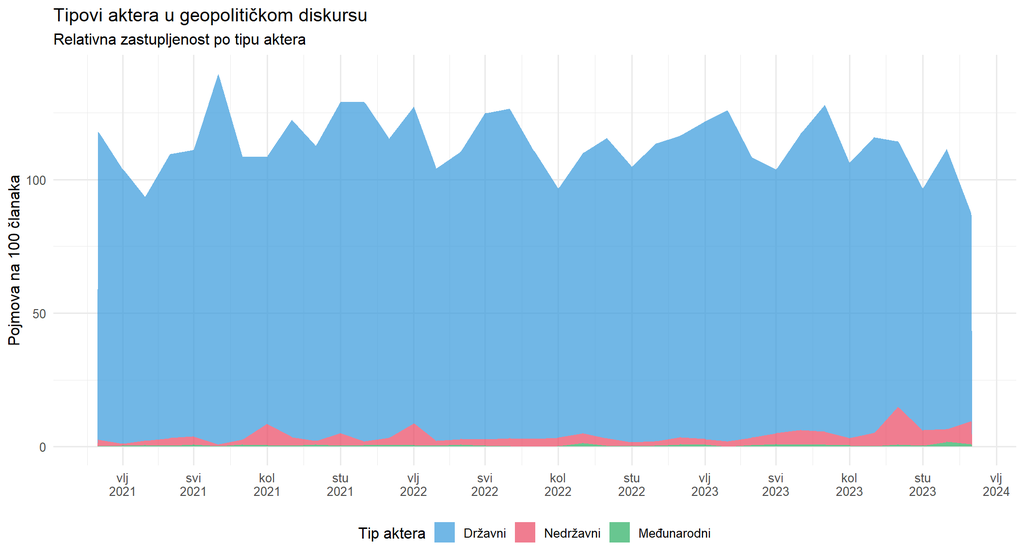

Tipovi aktera u geopolitičkom diskursu

## 7.3 Odnos neizvjesnosti i eskalacije

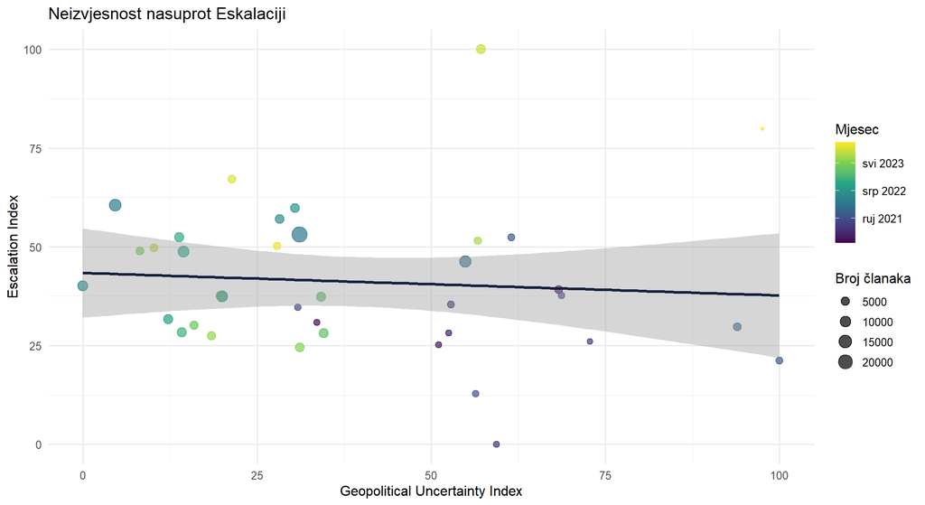

Odnos neizvjesnosti i eskalacije

# 8 Volatilnost i momentum

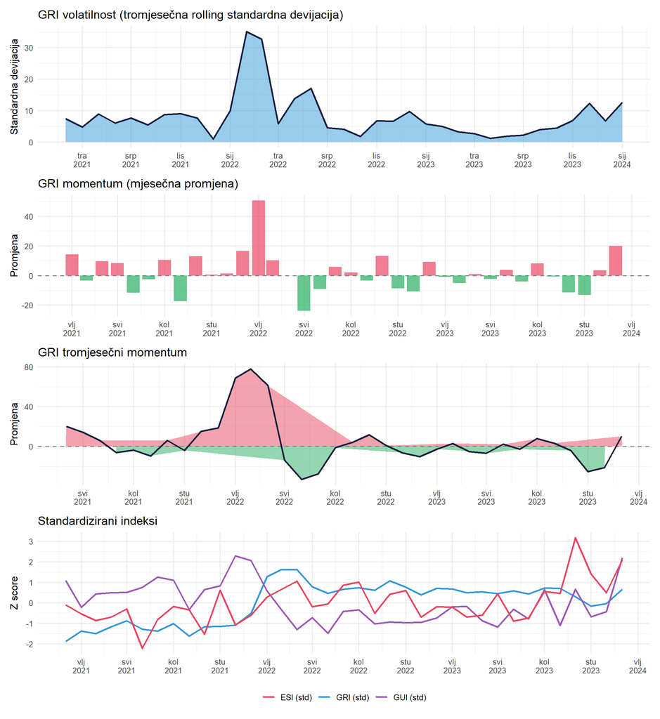

Volatilnost i momentum geopolitičkih indeksa

# 9 Koncentracija tema

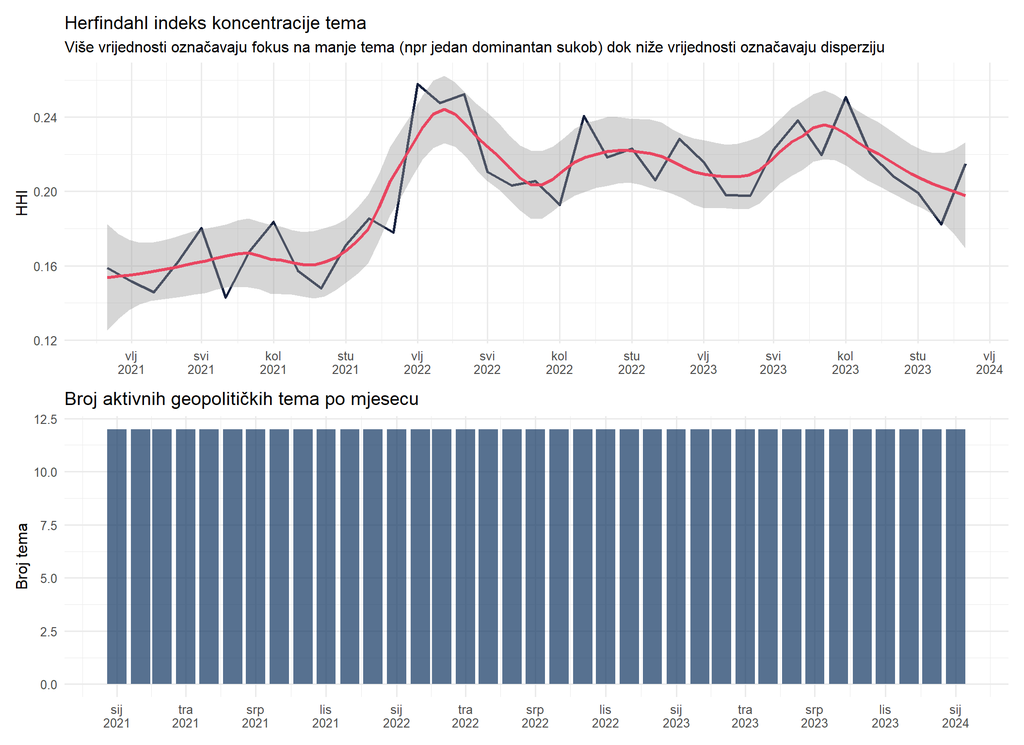

Koncentracija geopolitičkih tema

# 10 Lead Lag analiza

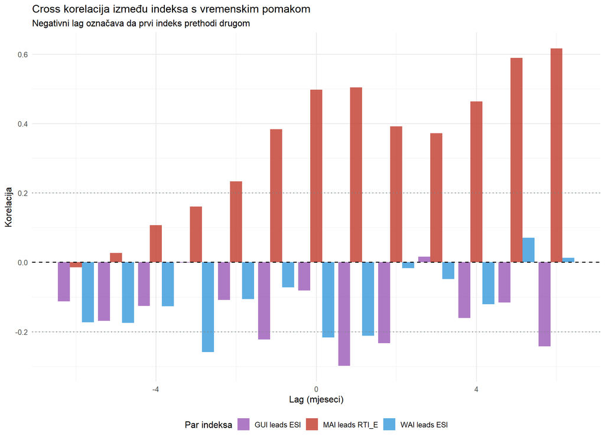

Lead lag analiza između ključnih indeksa

# 11 Validacija i kontrola kvalitete

Kontrola kvalitete podataka

| Provjera | Status |
| --- | --- |
| Pokrivenost razdoblja | OK |
| Minimalni članci po mjesecu | OK |
| Outlier mjeseci (GRI) | OK |
| Vremenski gapovi | OK |

**Napomene o ograničenjima**

Konstrukcija semantičkih indeksa temelji se na leksičkom pristupu koji ima inherentna ograničenja. Regularni izrazi mogu propustiti relevantne pojmove ili uključiti lažne pozitive. Normalizacija po broju članaka pretpostavlja stabilnu kvalitetu medijskog izvještavanja kroz vrijeme. PCA komponenta ovisi o strukturi korelacija u uzorku i može varirati s promjenama u fokusima medijskog izvještavanja.

Preporučuje se periodička validacija uzoraka tekstova i usporedba s eksternim pokazateljima geopolitičkog rizika.

# 12 Korelacije između indeksa

Korelacijska matrica geopolitičkih indeksa

|  | GRI | CII | ESI | GUI | FGI | RTI_E | METI | WAI | MAI | PCI |
| --- | --- | --- | --- | --- | --- | --- | --- | --- | --- | --- |
| GRI | 1.000 | 0.986 | 0.457 | -0.535 | 0.424 | 0.918 | -0.148 | 0.035 | 0.669 | 0.697 |
| CII | 0.986 | 1.000 | 0.499 | -0.505 | 0.398 | 0.904 | -0.085 | 0.021 | 0.638 | 0.678 |
| ESI | 0.457 | 0.499 | 1.000 | -0.081 | 0.129 | 0.199 | 0.537 | -0.217 | 0.397 | 0.249 |
| GUI | -0.535 | -0.505 | -0.081 | 1.000 | -0.046 | -0.575 | 0.266 | -0.176 | -0.349 | -0.414 |
| FGI | 0.424 | 0.398 | 0.129 | -0.046 | 1.000 | 0.435 | -0.144 | 0.189 | 0.116 | 0.255 |
| RTI_E | 0.918 | 0.904 | 0.199 | -0.575 | 0.435 | 1.000 | -0.467 | 0.199 | 0.498 | 0.739 |
| METI | -0.148 | -0.085 | 0.537 | 0.266 | -0.144 | -0.467 | 1.000 | -0.295 | 0.049 | -0.242 |
| WAI | 0.035 | 0.021 | -0.217 | -0.176 | 0.189 | 0.199 | -0.295 | 1.000 | -0.441 | 0.235 |
| MAI | 0.669 | 0.638 | 0.397 | -0.349 | 0.116 | 0.498 | 0.049 | -0.441 | 1.000 | 0.187 |
| PCI | 0.697 | 0.678 | 0.249 | -0.414 | 0.255 | 0.739 | -0.242 | 0.235 | 0.187 | 1.000 |

# 13 Export

# 14 Sažetak

Sažetak geopolitičke analize

| Metrika | Vrijednost |
| --- | --- |
| Broj analiziranih članaka | 218,162 |
| Vremenski raspon | 01/2021 do 01/2024 |
| Broj geopolitičkih kategorija | 66 |
| Broj makro tema | 12 |
| Broj konstruiranih indeksa | 10 |
| Prosječni GRI | 53.7 |
| Prosječni ESI (eskalacija) | 41.1 |
| Prosječni GUI (neizvjesnost) | 39.4 |

*Izvještaj generiran: 2026-01-01 13:55:37.078276*

*GIMES Research | Semantički indeks geopolitičke nestabilnosti v1.1*